# Logistic Regression model (1)

## Burns

`burn1000` in package `aplore3`: 1000 cases of burn injuries

```r
library(aplore3)
d <- burn1000         # just to have shorter name for the dataframe
head(d, 4)
```

```
  id facility death  age gender      race tbsa inh_inj flame
1  1       11 Alive 26.6   Male     White 25.3      No   Yes
2  2        1 Alive  2.0 Female Non-White  5.0      No    No
3  3       12 Alive 22.0 Female Non-White  2.0      No    No
4  4        1 Alive 37.3   Male     White  2.0      No    No
```

- `tbsa`: \(\qquad\) Total burn surface area (0 - 100%)
- `inh_inj`: \(\quad\) Burn involved inhalation injury
- `flame`: \(\qquad\) Flame involved in burn injury

## A summary of the data

```r
library(tidyverse)
d %>%
  select(-id, -facility) %>%
  summary()
```

```
   death          age           gender           race          tbsa
 Alive:850   Min.   : 0.10   Female:295   Non-White:411   Min.   : 0.10
 Dead :150   1st Qu.:10.85   Male  :705   White    :589   1st Qu.: 2.50
             Median :31.95                                Median : 6.00
             Mean   :33.29                                Mean   :13.54
             3rd Qu.:51.23                                3rd Qu.:16.00
             Max.   :89.70                                Max.   :98.00
 inh_inj   flame
 No :878   No :471
 Yes:122   Yes:529
```

## Modeling probabilities - Logistic function

Outcome coded as 1 for “Dead”, 0 for “Alive”. Does the *probability* of dying (\(\pi\)) increase with `tbsa` (\(x\))?

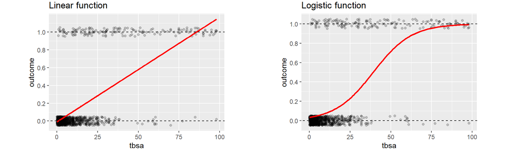

\(\pi = \beta_0 + \beta_1 x \qquad \qquad \qquad \qquad \pi = \frac{e^{\beta_0 + \beta_1 x}}{1 \enspace + \enspace e^{\beta_0 + \beta_1 x}}\)

## The logit transformation

\(\pi = \frac{e^{\beta_0 + \beta_1 x}}{1 \enspace + \enspace e^{\beta_0 + \beta_1 x}} = \frac{e^{LP}}{1 \enspace + \enspace e^{LP}} \qquad\) where \(\quad LP = \beta_0 + \beta_1 x\)

\(\frac{1}{\pi} = \frac{1 \enspace + \enspace e^{LP}}{e^{LP}} = \frac{1}{e^{LP}} + 1\)

\(\frac{1}{\pi} -1 = \frac{1}{e^{LP}}\)

\(\frac{1-\pi}{\pi} = \frac{1}{e^{LP}}\)

\(\frac{\pi}{1-\pi} = e^{LP} \quad \implies \quad ln(\frac{\pi}{1-\pi}) = \beta_0 + \beta_1 x\)

To note:

- \(ln(\frac{\pi}{1-\pi})\) is the *log-odds*, or the *logit* of \(\pi\)
- The logit of \(\pi\) is linearly related to x

## A first model based on `tbsa`

Use function `glm()` with option `familiy = binomial` !!  
You will be modeling the probability of the *second* level of `death` !!

```r
mod_s <- glm(death ~ tbsa, data = d, family=binomial)         # do not forget!  family=binomial
summary(mod_s)
```

```
Call:
glm(formula = death ~ tbsa, family = binomial, data = d)

Coefficients:
             Estimate Std. Error z value Pr(>|z|)
(Intercept) -3.345107   0.175648  -19.04   <2e-16 ***
tbsa         0.085367   0.006956   12.27   <2e-16 ***
---
Signif. codes:  0 '***' 0.001 '**' 0.01 '*' 0.05 '.' 0.1 ' ' 1

(Dispersion parameter for binomial family taken to be 1)

    Null deviance: 845.42  on 999  degrees of freedom
Residual deviance: 538.65  on 998  degrees of freedom
AIC: 542.65

Number of Fisher Scoring iterations: 5
```

## Interpreting coefficients of quantitative vars

\(ln(\frac{\pi}{1-\pi}) = \beta_0 + \beta_1 x\)

\(\beta_0 =\) log-odds when \(x=0\)

\(\beta_1 =\) change in log-odds per unit increment in \(x\)  
- \(x=k: \quad \qquad \beta_0 + \beta_1 k\)  
- \(x=k+1: \quad \beta_0 + \beta_1 (k+1) = \beta_0 + \beta_1 k + \beta_1\)

So that, \(\qquad \beta_1 = ln(\frac{\pi|x=k+1}{1-\pi|x=k+1}) - ln(\frac{\pi|x=k}{1-\pi|x=k}) = ln \left( \frac{\frac{\pi|x=k+1}{1-\pi|x=k+1}}{\frac{\pi|x=k}{1-\pi|x=k}} \right)\)  
Therefore, \(\qquad e^{\beta_1} = \frac{\frac{\pi|x=k+1}{1-\pi|x=k+1}}{\frac{\pi|x=k}{1-\pi|x=k}} \qquad\) is the OR for a unit increment in \(x\)

## Exponentiate coefficients to interpret

```r
coef(mod_s); exp(coef(mod_s))
```

```
(Intercept)        tbsa
-3.34510747  0.08536677
```

```
(Intercept)        tbsa
 0.03525643  1.08911645
```

The odds when `tbsa`=0: \(\quad \text{O}_0 =\) 0.04  
(meaningless in this case, since `tbsa`=0 means no burn!)

The OR for a unit increase in `tbsa`: \(\quad \text{OR}_1 =\) 1.09

In general, the OR for a \(k\) units increase is \((\text{OR}_1)^k\), therefore

The OR for a 10 units increase in `tbsa`: \(\quad\) (1.09)\(^{10}\) = 2.35

## Exponentiate the CI of coefficients also

```r
exp(coef(mod_s))           # exponential of coefficients
```

```
(Intercept)        tbsa
 0.03525643  1.08911645
```

```r
exp(confint(mod_s))        # and their 95% CI
```

```
                 2.5 %     97.5 %
(Intercept) 0.02461148 0.04906045
tbsa        1.07508450 1.10483341
```

The OR for a unit increase in `tbsa` is \(\quad\) 1.09 [1.08, 1.1]

and raising these values to 10…

The OR for a 10 units increase in `tbsa` is \(\quad\) 2.35 [2.06, 2.71]

## A second model, based on `inh_inj`

```r
mod_i <- glm(death ~ inh_inj, data = d, family=binomial)
summary(mod_i)
```

```
Call:
glm(formula = death ~ inh_inj, family = binomial, data = d)

Coefficients:
            Estimate Std. Error z value Pr(>|z|)
(Intercept)  -2.3279     0.1186  -19.62   <2e-16 ***
inh_injYes    2.6925     0.2190   12.29   <2e-16 ***
---
Signif. codes:  0 '***' 0.001 '**' 0.01 '*' 0.05 '.' 0.1 ' ' 1

(Dispersion parameter for binomial family taken to be 1)

    Null deviance: 845.42  on 999  degrees of freedom
Residual deviance: 691.66  on 998  degrees of freedom
AIC: 695.66

Number of Fisher Scoring iterations: 5
```

## Interpreting (exponentiated) coefficients

If explanatory variable is a factor, the *exponentials* of coefficients are:

- `Intercept`: the odds of dead for the reference level (no inhalation injury)
- `inh_injYes`: the OR of dead (Inhalation injury / no inhalation injury)

```r
exp(coef(mod_i))
```

```
(Intercept)  inh_injYes
    0.09750    14.76923
```

```r
library(mosaic); tally(death ~ inh_inj, data=d)
```

```
       inh_inj
death    No Yes
  Alive 800  50
  Dead   78  72
```

## Exercise

1. Read the [Titanic data](https://raw.githubusercontent.com/acobos/Datasets/master/Mysterious_event.txt) with the following code:

   ```r
   d <- rio::import("https://raw.githubusercontent.com/acobos/Datasets/master/Mysterious_event.txt",
                stringsAsFactors  = TRUE)
   ```

   - What are the levels of `Survival`? Which level will be modelled in a logistic regression analysis using `glm(..., family = binomial)`?
   - Fit a logistic regression model (`m1`) for `Survival` with only `Class` as predictor, and get the model summary.
   - Based on the summary, what class has the lowest survival probability?
   - What is the OR of survival for class S compared to class 1?
   - What is the OR of survival for class 1 compared to class S?